# PTSD Questions

### Vanguard graphs

Vanguard Survey – PTSD Questions  
“Below is a list of problems that people sometimes have in response to a very stressful experience. Please read each problem carefully and then circle one of the numbers to the right to indicate how much you have been bothered by that problem in the past 30 days. In the past 30 days, how much were you bothered by:”

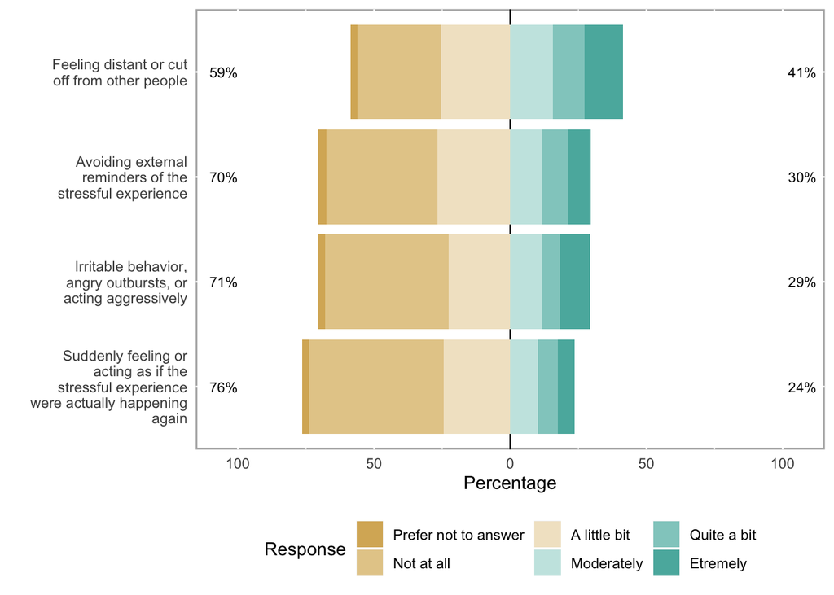

Vanguard Survey – PTSD Questions, by Youth Arm variable  
“Below is a list of problems that people sometimes have in response to a very stressful experience. Please read each problem carefully and then circle one of the numbers to the right to indicate how much you have been bothered by that problem in the past 30 days. In the past 30 days, how much were you bothered by:”

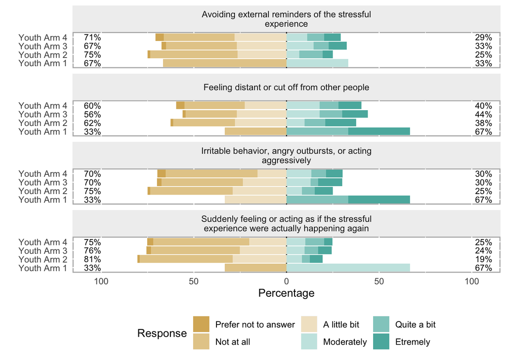

### Vanguard Tables

**“Suddenly feeling or acting as if the stressful experience were actually happening again”**

| arm | NA_ | Prefer not to answer | Not at all | A little bit | Moderately | Quite a bit | Etremely | Total |
| --- | --- | --- | --- | --- | --- | --- | --- | --- |
| Youth Arm 1 | 0 (81.2%) | 0 (0.0%) | 2 (6.2%) | 1 (0.0%) | 0 (12.5%) | 0 (0.0%) | 13 (0.0%) | 16 (100.0%) |
| Youth Arm 2 | 21 (83.4%) | 5 (0.2%) | 6 (8.3%) | 36 (4.8%) | 1 (1.4%) | 3 (0.7%) | 362 (1.2%) | 434 (100.0%) |
| Youth Arm 3 | 31 (76.1%) | 9 (0.6%) | 12 (11.5%) | 59 (6.0%) | 3 (2.3%) | 9 (1.8%) | 391 (1.8%) | 514 (100.0%) |
| Youth Arm 4 | 18 (84.2%) | 4 (0.5%) | 9 (8.2%) | 46 (3.2%) | 3 (1.6%) | 9 (1.6%) | 475 (0.7%) | 564 (100.0%) |
| Total | 70 (81.2%) | 18 (0.5%) | 29 (9.3%) | 142 (4.6%) | 7 (1.9%) | 21 (1.4%) | 1241 (1.2%) | 1528 (100.0%) |

**“Avoiding external reminders of the stressful experience”**

| arm | NA_ | Prefer not to answer | Not at all | A little bit | Moderately | Quite a bit | Etremely | Total |
| --- | --- | --- | --- | --- | --- | --- | --- | --- |
| Youth Arm 1 | 0 (81.2%) | 0 (0.0%) | 1 (12.5%) | 2 (0.0%) | 0 (6.2%) | 0 (0.0%) | 13 (0.0%) | 16 (100.0%) |
| Youth Arm 2 | 19 (83.4%) | 4 (0.2%) | 5 (7.8%) | 34 (4.4%) | 1 (1.2%) | 9 (2.1%) | 362 (0.9%) | 434 (100.0%) |
| Youth Arm 3 | 33 (76.1%) | 12 (0.6%) | 18 (9.1%) | 47 (6.4%) | 3 (3.5%) | 10 (1.9%) | 391 (2.3%) | 514 (100.0%) |
| Youth Arm 4 | 25 (84.2%) | 8 (0.7%) | 10 (6.0%) | 34 (4.4%) | 4 (1.8%) | 8 (1.4%) | 475 (1.4%) | 564 (100.0%) |
| Total | 77 (81.2%) | 24 (0.5%) | 34 (7.7%) | 117 (5.0%) | 8 (2.2%) | 27 (1.8%) | 1241 (1.6%) | 1528 (100.0%) |

**“Feeling distant or cut off from other people”**

| arm | NA_ | Prefer not to answer | Not at all | A little bit | Moderately | Quite a bit | Etremely | Total |
| --- | --- | --- | --- | --- | --- | --- | --- | --- |
| Youth Arm 1 | 0 (81.2%) | 1 (0.0%) | 0 (6.2%) | 1 (0.0%) | 0 (0.0%) | 1 (6.2%) | 13 (6.2%) | 16 (100.0%) |
| Youth Arm 2 | 20 (83.4%) | 12 (0.2%) | 7 (5.5%) | 24 (4.6%) | 1 (1.6%) | 8 (1.8%) | 362 (2.8%) | 434 (100.0%) |
| Youth Arm 3 | 33 (76.1%) | 17 (0.4%) | 22 (6.6%) | 34 (6.4%) | 2 (4.3%) | 15 (2.9%) | 391 (3.3%) | 514 (100.0%) |
| Youth Arm 4 | 20 (84.2%) | 11 (0.7%) | 16 (5.1%) | 29 (3.5%) | 4 (2.8%) | 9 (1.6%) | 475 (2.0%) | 564 (100.0%) |
| Total | 73 (81.2%) | 41 (0.5%) | 45 (5.8%) | 88 (4.8%) | 7 (2.9%) | 33 (2.2%) | 1241 (2.7%) | 1528 (100.0%) |

**“Irritable behavior, angry outbursts, or acting aggressively”**

| arm | NA_ | Prefer not to answer | Not at all | A little bit | Moderately | Quite a bit | Etremely | Total |
| --- | --- | --- | --- | --- | --- | --- | --- | --- |
| Youth Arm 1 | 1 (81.2%) | 1 (0.0%) | 0 (0.0%) | 0 (6.2%) | 0 (0.0%) | 1 (6.2%) | 13 (6.2%) | 16 (100.0%) |
| Youth Arm 2 | 21 (83.4%) | 7 (0.2%) | 6 (7.4%) | 32 (4.8%) | 1 (1.4%) | 5 (1.2%) | 362 (1.6%) | 434 (100.0%) |
| Youth Arm 3 | 29 (76.1%) | 16 (0.6%) | 16 (10.5%) | 54 (5.6%) | 3 (3.1%) | 5 (1.0%) | 391 (3.1%) | 514 (100.0%) |
| Youth Arm 4 | 14 (84.2%) | 8 (0.7%) | 12 (7.8%) | 44 (2.5%) | 4 (2.1%) | 7 (1.2%) | 475 (1.4%) | 564 (100.0%) |
| Total | 65 (81.2%) | 32 (0.5%) | 34 (8.5%) | 130 (4.3%) | 8 (2.2%) | 18 (1.2%) | 1241 (2.1%) | 1528 (100.0%) |

### G2C graphs

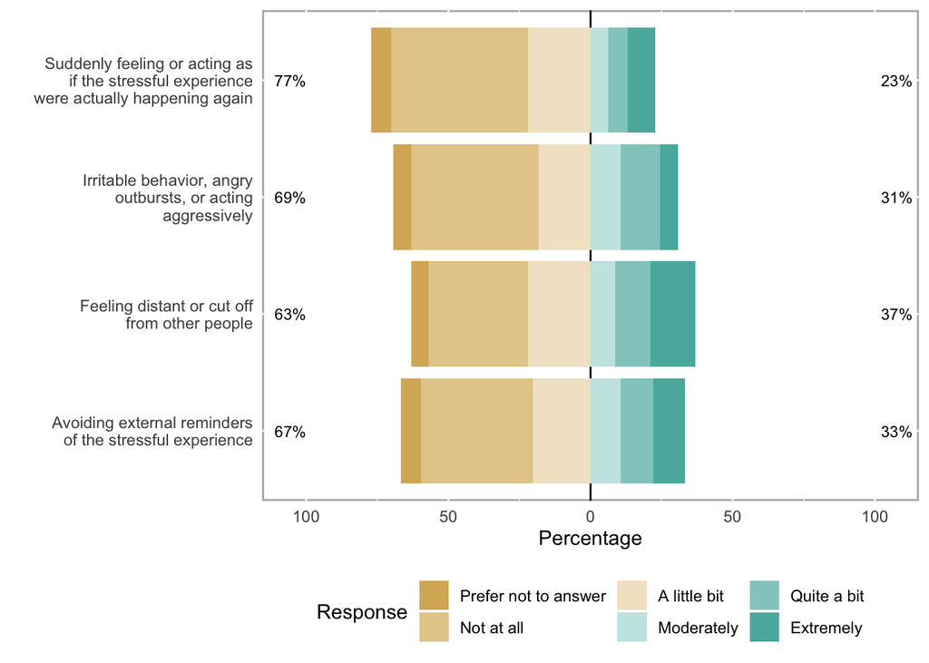

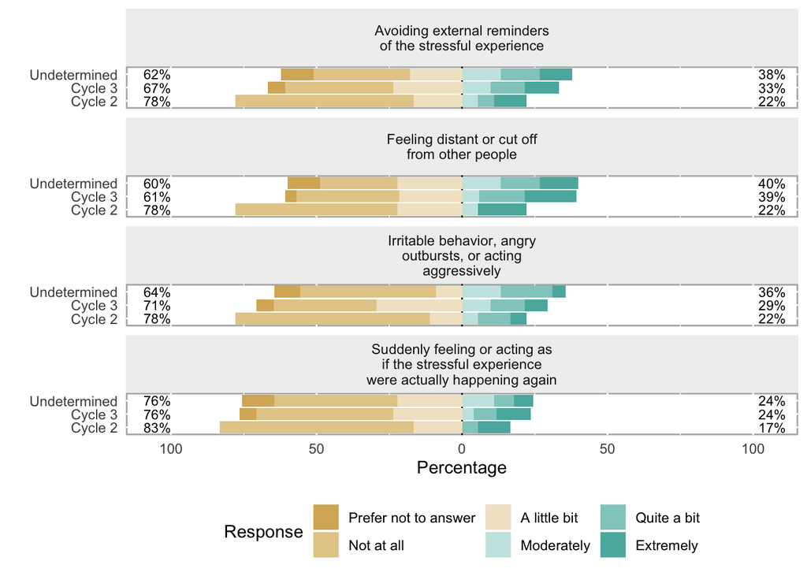

### G2C Tables

**“Suddenly feeling or acting as if the stressful experience were actually happening again”**

| cycle1 | Prefer not to answer | Not at all | A little bit | Moderately | Quite a bit | Extremely | Total |
| --- | --- | --- | --- | --- | --- | --- | --- |
| Cycle 2 | 3 (0.0%) | 2 (66.7%) | 0 (16.7%) | 12 (0.0%) | 0 (5.6%) | 1 (11.1%) | 18 (100.0%) |
| Cycle 3 | 12 (5.9%) | 6 (47.1%) | 2 (23.5%) | 24 (3.9%) | 3 (7.8%) | 4 (11.8%) | 51 (100.0%) |
| Undetermined | 10 (11.1%) | 3 (42.2%) | 5 (22.2%) | 19 (11.1%) | 5 (6.7%) | 3 (6.7%) | 45 (100.0%) |
| Total | 25 (7.0%) | 11 (48.2%) | 7 (21.9%) | 55 (6.1%) | 8 (7.0%) | 8 (9.6%) | 114 (100.0%) |

**“Avoiding external reminders of the stressful experience”**

| cycle1 | Prefer not to answer | Not at all | A little bit | Moderately | Quite a bit | Extremely | Total |
| --- | --- | --- | --- | --- | --- | --- | --- |
| Cycle 2 | 3 (0.0%) | 2 (61.1%) | 1 (16.7%) | 11 (5.6%) | 0 (5.6%) | 1 (11.1%) | 18 (100.0%) |
| Cycle 3 | 12 (5.9%) | 6 (37.3%) | 5 (23.5%) | 19 (9.8%) | 3 (11.8%) | 6 (11.8%) | 51 (100.0%) |
| Undetermined | 8 (11.1%) | 5 (33.3%) | 6 (17.8%) | 15 (13.3%) | 5 (13.3%) | 6 (11.1%) | 45 (100.0%) |
| Total | 23 (7.0%) | 13 (39.5%) | 12 (20.2%) | 45 (10.5%) | 8 (11.4%) | 13 (11.4%) | 114 (100.0%) |

**“Feeling distant or cut off from other people”**

| cycle1 | Prefer not to answer | Not at all | A little bit | Moderately | Quite a bit | Extremely | Total |
| --- | --- | --- | --- | --- | --- | --- | --- |
| Cycle 2 | 4 (0.0%) | 3 (55.6%) | 1 (22.2%) | 10 (5.6%) | 0 (0.0%) | 0 (16.7%) | 18 (100.0%) |
| Cycle 3 | 11 (3.9%) | 9 (35.3%) | 3 (21.6%) | 18 (5.9%) | 2 (15.7%) | 8 (17.6%) | 51 (100.0%) |
| Undetermined | 10 (11.1%) | 6 (26.7%) | 6 (22.2%) | 12 (13.3%) | 5 (13.3%) | 6 (13.3%) | 45 (100.0%) |
| Total | 25 (6.1%) | 18 (35.1%) | 10 (21.9%) | 40 (8.8%) | 7 (12.3%) | 14 (15.8%) | 114 (100.0%) |

**“Irritable behavior, angry outbursts, or acting aggressively”**

| cycle1 | Prefer not to answer | Not at all | A little bit | Moderately | Quite a bit | Extremely | Total |
| --- | --- | --- | --- | --- | --- | --- | --- |
| Cycle 2 | 2 (0.0%) | 1 (66.7%) | 1 (11.1%) | 12 (5.6%) | 0 (11.1%) | 2 (5.6%) | 18 (100.0%) |
| Cycle 3 | 15 (5.9%) | 4 (35.3%) | 5 (29.4%) | 18 (9.8%) | 3 (11.8%) | 6 (7.8%) | 51 (100.0%) |
| Undetermined | 4 (8.9%) | 2 (46.7%) | 6 (8.9%) | 21 (13.3%) | 4 (17.8%) | 8 (4.4%) | 45 (100.0%) |
| Total | 21 (6.1%) | 7 (44.7%) | 12 (18.4%) | 51 (10.5%) | 7 (14.0%) | 16 (6.1%) | 114 (100.0%) |

### Vanguard vs. G2C

**“Below is a list of problems that people sometimes have in response to a very stressful experience. Please read each problem carefully and then circle one of the numbers to the right to indicate how much you have been bothered by that problem in the past 30 days. In the past 30 days, how much were you bothered by:”**

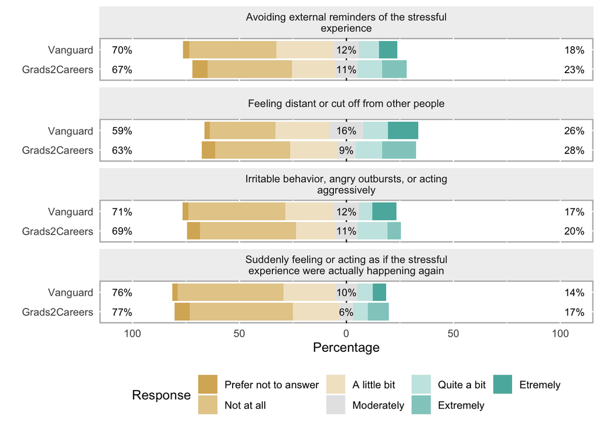

**Histogram of ptsd Scores (total of 4 variables, range:0-16): Vanguard vs. G2C**

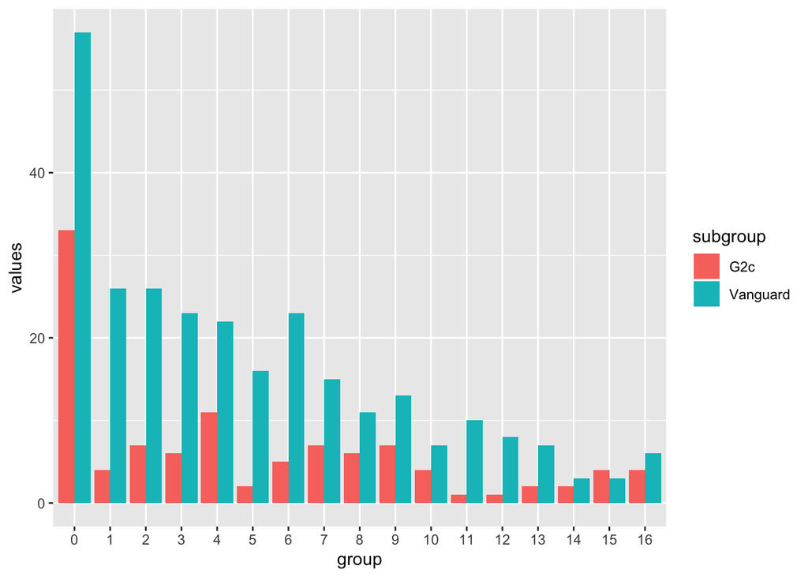

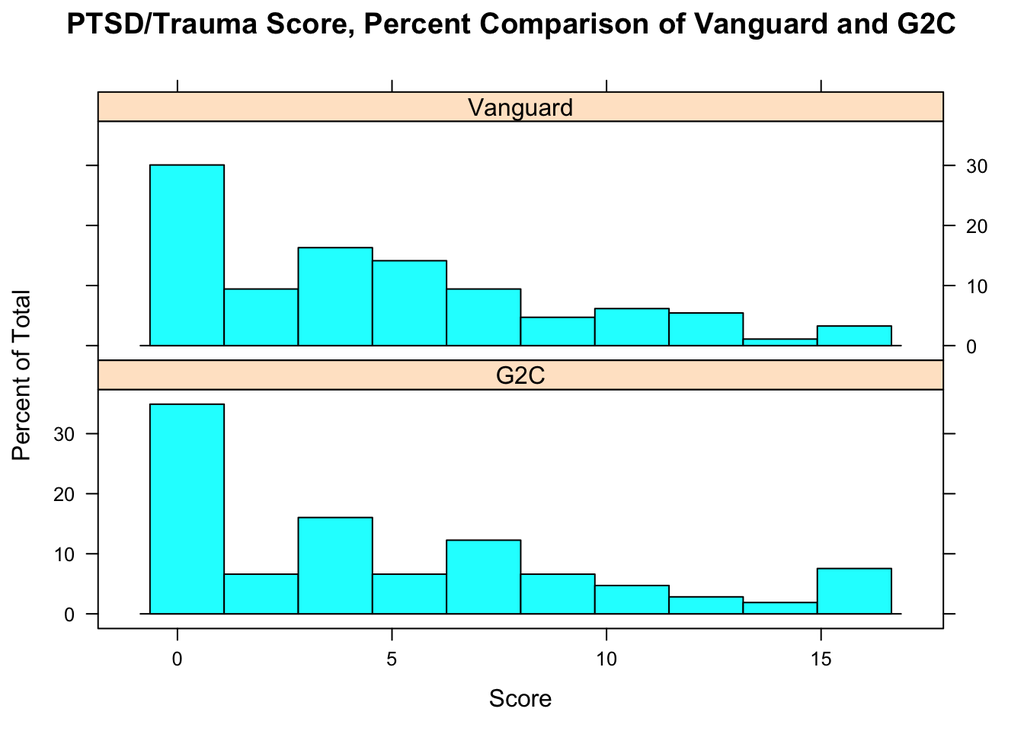

```
##
##  Wilcoxon rank sum test with continuity correction
##
## data:  ptsd_total_merged$ptsd_total_no_refused by ptsd_total_merged$study
## W = 14340, p-value = 0.7642
## alternative hypothesis: true location shift is not equal to 0
```

```
##
##  Welch Two Sample t-test
##
## data:  ptsd_total_merged$ptsd_total_no_refused by ptsd_total_merged$study
## t = 0.28955, df = 171.58, p-value = 0.7725
## alternative hypothesis: true difference in means is not equal to 0
## 95 percent confidence interval:
##  -0.9182237  1.2339196
## sample estimates:
##      mean in group G2C mean in group Vanguard
##               4.915094               4.757246
```

ptsd Score comparison

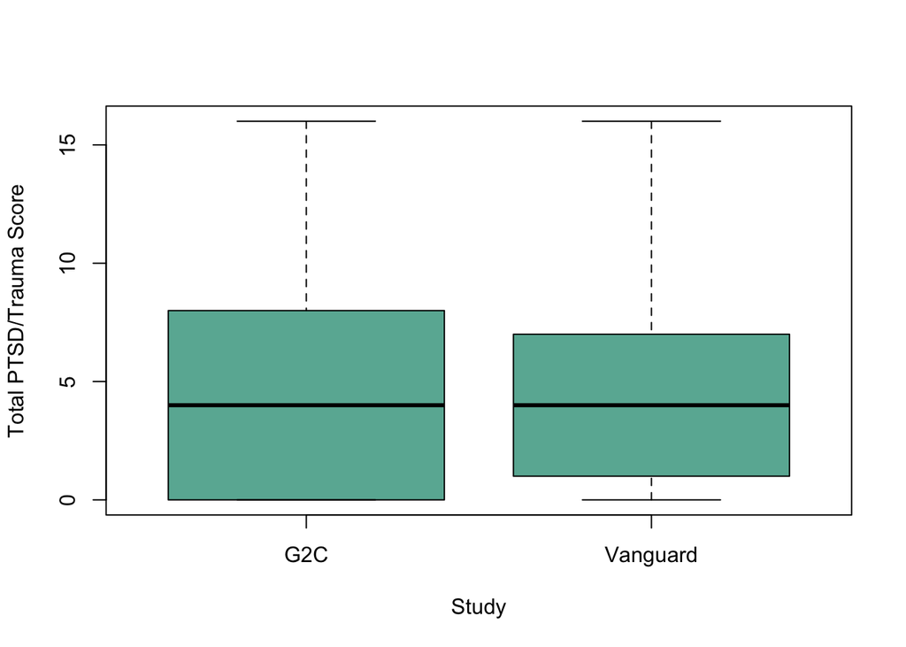